# Flight Delay Assignment

Harichandana Gonuguntla/U1448647

02/19/2023

## Load packages and data

```r
# Load packages
library(tidyverse)

# Load data
d <- read_csv("flight_delay_clean.csv")

# Inspect data
glimpse(d)
```

```
## Rows: 360
## Columns: 13
## $ airline                 <chr> "RegionEx", "RegionEx", "RegionEx", "RegionEx"…
## $ departure_date          <date> 2008-09-01, 2008-09-01, 2008-09-01, 2008-09-0…
## $ origin                  <chr> "DFW", "DFW", "DFW", "DFW", "DFW", "DFW", "DFW…
## $ destination             <chr> "MSY", "MSY", "MSY", "MSY", "MSY", "MSY", "MSY…
## $ route_code              <chr> "DFW/MSY", "DFW/MSY", "DFW/MSY", "DFW/MSY", "D…
## $ scheduled_departure     <time> 09:10:00, 13:10:00, 18:10:00, 09:10:00, 13:10…
## $ scheduled_arrival       <time> 10:40:00, 14:40:00, 19:40:00, 10:40:00, 14:40…
## $ actual_arrival          <time> 11:00:00, 15:00:00, 19:58:00, 10:50:00, 14:51…
## $ scheduled_flight_length <dbl> 90, 90, 90, 90, 90, 90, 90, 90, 90, 90, 90, 90…
## $ actual_flight_length    <dbl> 110, 110, 108, 100, 101, 100, 99, 99, 99, 100,…
## $ delay                   <dbl> 20, 20, 18, 10, 11, 10, 9, 9, 9, 10, 10, 9, 13…
## $ delay_indicator         <dbl> 1, 1, 1, 0, 0, 0, 0, 0, 0, 0, 0, 0, 0, 0, 0, 0…
## $ day_of_week             <dbl> 2, 2, 2, 3, 3, 3, 4, 4, 4, 5, 5, 5, 6, 6, 6, 7…
```

```r
summary(d)
```

```
##    airline          departure_date          origin          destination
##  Length:360         Min.   :2008-09-01   Length:360         Length:360
##  Class :character   1st Qu.:2008-09-08   Class :character   Class :character
##  Mode  :character   Median :2008-09-15   Mode  :character   Mode  :character
##                     Mean   :2008-09-15
##                     3rd Qu.:2008-09-23
##                     Max.   :2008-09-30
##   route_code        scheduled_departure scheduled_arrival actual_arrival
##  Length:360         Length:360          Length:360        Length:360
##  Class :character   Class1:hms          Class1:hms        Class1:hms
##  Mode  :character   Class2:difftime     Class2:difftime   Class2:difftime
##                     Mode  :numeric      Mode  :numeric    Mode  :numeric
##
##
##  scheduled_flight_length actual_flight_length     delay        delay_indicator
##  Min.   : 70.00          Min.   : 59.00       Min.   :-13.00   Min.   :0.0000
##  1st Qu.: 75.00          1st Qu.: 86.00       1st Qu.:  5.00   1st Qu.:0.0000
##  Median : 90.00          Median : 97.00       Median : 11.00   Median :0.0000
##  Mean   : 85.83          Mean   : 99.91       Mean   : 14.07   Mean   :0.2611
##  3rd Qu.: 90.00          3rd Qu.:108.25       3rd Qu.: 15.00   3rd Qu.:1.0000
##  Max.   :100.00          Max.   :243.00       Max.   :153.00   Max.   :1.0000
##   day_of_week
##  Min.   :1.0
##  1st Qu.:2.0
##  Median :4.0
##  Mean   :3.9
##  3rd Qu.:6.0
##  Max.   :7.0
```

The dataset has been cleaned for you and is ready for analysis.

## Questions

Lightly comment your code and use pipes for readability.

Most of the questions require some writing. Please place your text immediately after the “>” in each question, which will make it into a block quote.

Comment briefly on each of the questions, as directed. Only the the final question requires a lengthier response.

### Q1

Compute the mean, median, 90th percentile, and standard deviation of arrival delay minutes for RegionEx flights. Do the same for MDA flights. Which measure of central tendency would be most appropriate for comparing airline performance?

```r
d%>%
group_by(airline)%>%
summarize(avg =mean(delay),
          median = median(delay),
          perc_90 = quantile(delay,probs = c(0.9)),
          sd = sd(delay))
```

```
## # A tibble: 2 × 5
##   airline    avg median perc_90    sd
##   <chr>    <dbl>  <dbl>   <dbl> <dbl>
## 1 MDA       10.9     13    16.1  6.34
## 2 RegionEx  15.7      9    21   27.7
```

> Median would be the most appropriate measure of central tendency for comparing the airline performance in our case. Since the data set we are using to calculate delay has some outliers and the distribution is a bit skewed , median would be more appropriate one here instead of mean(which is also a most commonly used measure which best fits for unskewed data)

### Q2

Inspect the distribution of RegionEx’s arrival delays by constructing a histogram of the number of arrival delay minutes of RegionEx’s flights. Do the same for MDA’s flights. How do these two distributions compare? Hint: use facet_wrap().

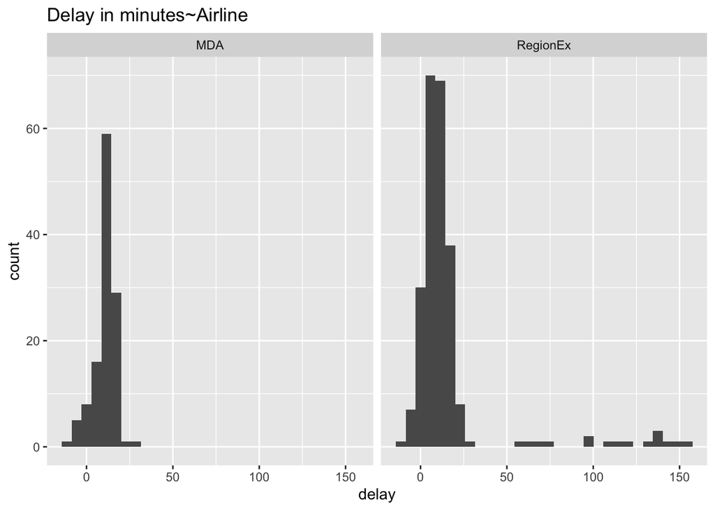

```r
# facet_wrap
ggplot(data = d, aes(x = delay)) +
  geom_histogram() +
  facet_wrap(~airline) +
  labs(title = "Delay in minutes~Airline")
```

> From the above histogram plot, we can mainly see that RegionEx delays are more than that of MDA and also the no.of flights operated under RegionEx are more than MDA. But, since RegionEx has larger delays we cannot just say outright that RegionEx performance is bad. Here RegionEx data has outliers and we cannot rely on mean delay to compare the airline performance.

### Q3

So far we have considered airline performance in terms of average delay in minutes. However, the performance metrics, as noted in the case description, also include the percentage of delayed flights. Let’s verify that MDA’s COO is correct: does RegionEx have a higher percentage of delayed flights?

Here is code to answer that question:

```r
# Create a summary table of percent delayed by airline.
d %>%
  group_by(airline) %>%
  summarize(n = n(),
            percent_delay = (mean(delay_indicator) * 100) %>% round(1))
```

```
## # A tibble: 2 × 3
##   airline      n percent_delay
##   <chr>    <int>         <dbl>
## 1 MDA        120          25.8
## 2 RegionEx   240          26.2
```

Note that because `delay_indicator` is numeric (a binary 0/1 variable) calculating the mean of the vector returns the proportion of 1s, which, multiplied by 100, is equivalent to the *percentage* of delayed flights.

Write your own code to create a table summarizing the percentage of delayed flights by airline *and route.*

```r
d %>%
  group_by(airline,route_code) %>%
  summarize(no.of_flights = n(),
            percent_delay = (mean(delay_indicator) * 100) %>% round(1))
```

```
## # A tibble: 8 × 4
## # Groups:   airline [2]
##   airline  route_code no.of_flights percent_delay
##   <chr>    <chr>              <int>         <dbl>
## 1 MDA      DFW/MSY               30          26.7
## 2 MDA      MSY/DFW               30          30
## 3 MDA      MSY/PNS               30          20
## 4 MDA      PNS/MSY               30          26.7
## 5 RegionEx DFW/MSY               90          25.6
## 6 RegionEx MSY/DFW               90          28.9
## 7 RegionEx MSY/PNS               30          20
## 8 RegionEx PNS/MSY               30          26.7
```

These tables contain conflicting information. How should you answer the question of whether RegionEx has a higher percentage of delayed flights? Is the the COO correct? And, if not, why not?

### Q4

Compare the scheduled flight durations for the two airlines on each of their four routes. Also compare the actual flight durations for the two airlines. What do you notice? If the two airlines had the same scheduled duration, what impact would this have on their delay records?

```r
d %>%
  group_by(route_code,airline) %>%
  summarize(no.of_flights = n(),
         avg_scheduled_flight_length = median(scheduled_flight_length),
         avg_actual_flight_length = median(actual_flight_length),
        difference = avg_scheduled_flight_length - avg_actual_flight_length)
```

```
## # A tibble: 8 × 6
## # Groups:   route_code [4]
##   route_code airline  no.of_flights avg_scheduled_flight_length avg_ac…¹ diffe…²
##   <chr>      <chr>            <int>                       <dbl>    <dbl>   <dbl>
## 1 DFW/MSY    MDA                 30                         100    114.    -13.5
## 2 DFW/MSY    RegionEx            90                          90    100     -10
## 3 MSY/DFW    MDA                 30                         100    113     -13
## 4 MSY/DFW    RegionEx            90                          90     99      -9
## 5 MSY/PNS    MDA                 30                          75     86     -11
## 6 MSY/PNS    RegionEx            30                          70     76.5    -6.5
## 7 PNS/MSY    MDA                 30                          75     79.5    -4.5
## 8 PNS/MSY    RegionEx            30                          70     77.5    -7.5
## # … with abbreviated variable names ¹avg_actual_flight_length, ²difference
```

> (***Here I have used median as a measure since actual_flight_length data has outliers).The difference between average scheduled flight length and average actual flight length for MDA is more in almost 3 routes.That means flights operated by MDA are experiencing more delays because the difference between the time they are expected to arrive and the actual time they arrived is more for MDA operated flights. If the 2 airlines had same scheduled duration, then in that case the difference calculated as above would be still less for RegionEx flights than MDA and the performance of RegionEx would still be more as it has lesser delays than MDA.

### Q5

Does the data support the claim that the on‐time performance of RegionEx is worse than that of MDA? Write a paragraph in which you argue a position. In your answer, please incorporate quantitative evidence from the earlier questions.